# DANG_final_project_EDA

Michael Li

================================================================================

This report is to explore a dataset containing red wine quality and other attribute for around 1599 samples.

data introductioin: This is Reb Wine Quality data set. Contain1599 red wines with 11 varaibles on the chemical properties of the wine

# Univariate Plots Section

### How many observations?

```
## [1] 1599
```

Total 1599 observation

### Which columns/factors we are measuring?

```
##  [1] "fixed.acidity"        "volatile.acidity"     "citric.acid"
##  [4] "residual.sugar"       "chlorides"            "free.sulfur.dioxide"
##  [7] "total.sulfur.dioxide" "density"              "pH"
## [10] "sulphates"            "alcohol"              "quality"
```

### How does the quality of wine distribute among dataset?

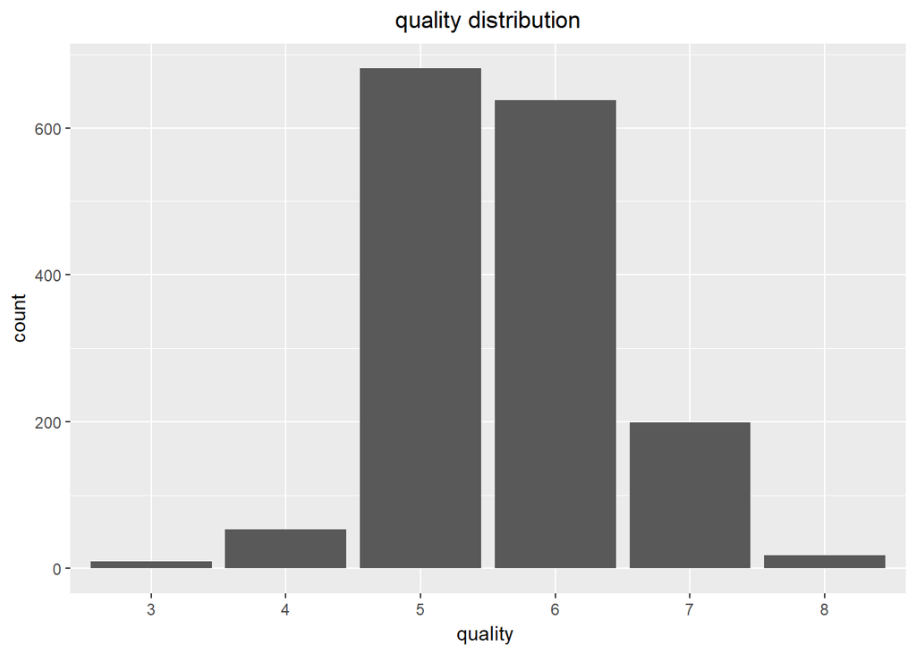

most of quality is 5 or 6

### How alcohol distribute among this dataset

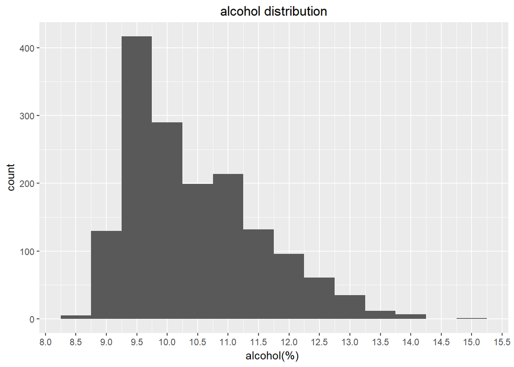

```
##    Min. 1st Qu.  Median    Mean 3rd Qu.    Max.
##    8.40    9.50   10.20   10.42   11.10   14.90
```

### How PH distribute among this dateset

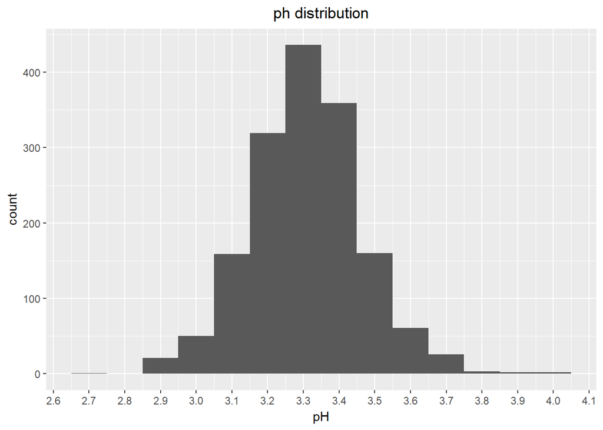

```
##    Min. 1st Qu.  Median    Mean 3rd Qu.    Max.
##   2.740   3.210   3.310   3.311   3.400   4.010
```

majority of ph is under under 3.05 ~3.65. Close to normal distribution

### how fixed.acidity distribute among this dataset

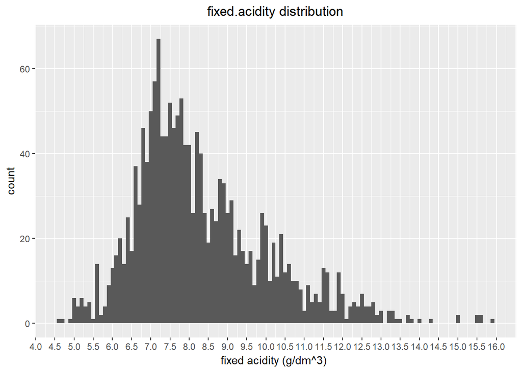

```
##    Min. 1st Qu.  Median    Mean 3rd Qu.    Max.
##    4.60    7.10    7.90    8.32    9.20   15.90
```

majority of fixed.acidity is under around 6.5~10. Some extrem highv value in fixed.acidity

### how density distribute among this dateset

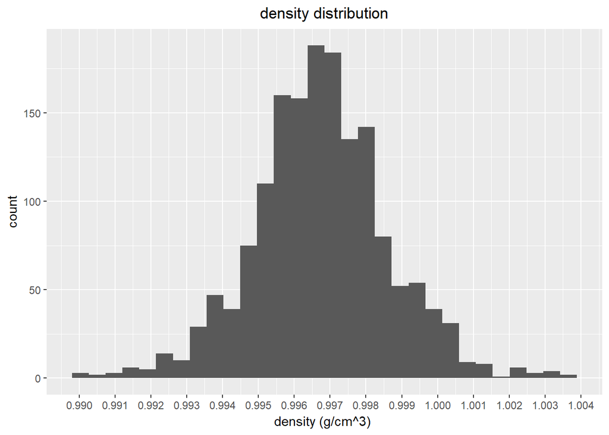

```
##    Min. 1st Qu.  Median    Mean 3rd Qu.    Max.
##  0.9901  0.9956  0.9968  0.9967  0.9978  1.0037
```

majority of density is under around 0.995 to 1.000. Close to normal distribution

### how sulphates distribute among this dateset

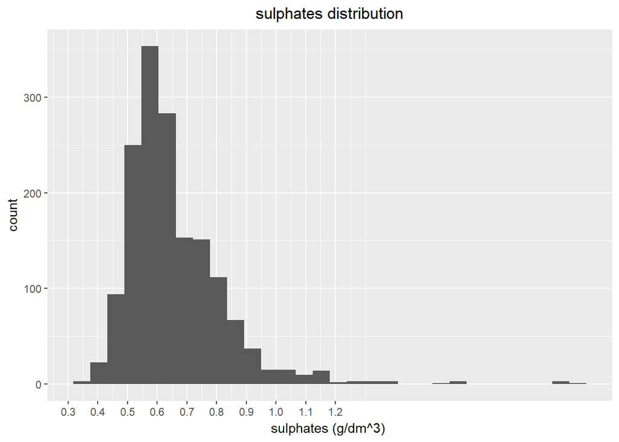

```
##    Min. 1st Qu.  Median    Mean 3rd Qu.    Max.
##  0.3300  0.5500  0.6200  0.6581  0.7300  2.0000
```

### how volatile.acidity distribute among this dateset

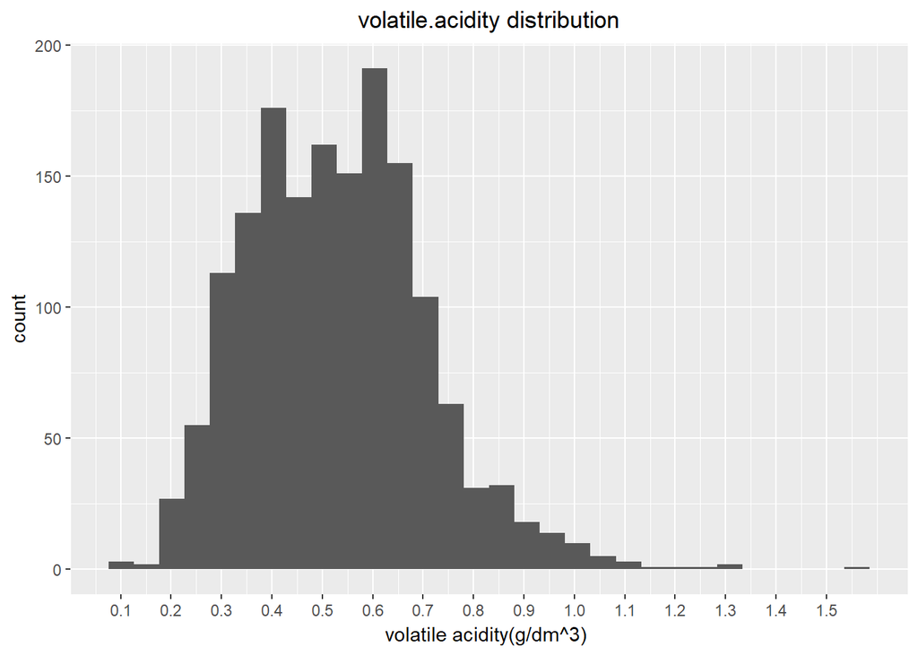

```
##    Min. 1st Qu.  Median    Mean 3rd Qu.    Max.
##  0.1200  0.3900  0.5200  0.5278  0.6400  1.5800
```

Most volatile.acidity is between 0.2 and 0.8 group

# Univariate Analysis

### What is the structure of your dataset?

This is 1599 variable. And 12 dimention of the wine data involved.

All of dimention is numerical data

### What is/are the main feature(s) of interest in your dataset?

fixed.acidity,pH,alchol,quality,density

### What other features in the dataset do you think will help support your investigation into your feature(s) of interest?

volcatile.acidity, citric.acid,residual.sugar

### Did you create any new variables from existing variables in the dataset?

Yes.I create quality_category since extreme value is small and may cause biased

### how quality category distibute

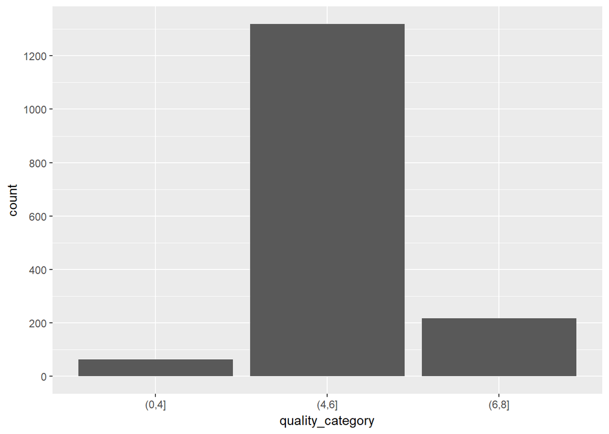

after put the quality into category, we can put our focus on the most common group (4,6].

# Bivariate Plots Section

### relationship between combination of each two factors and coefficient

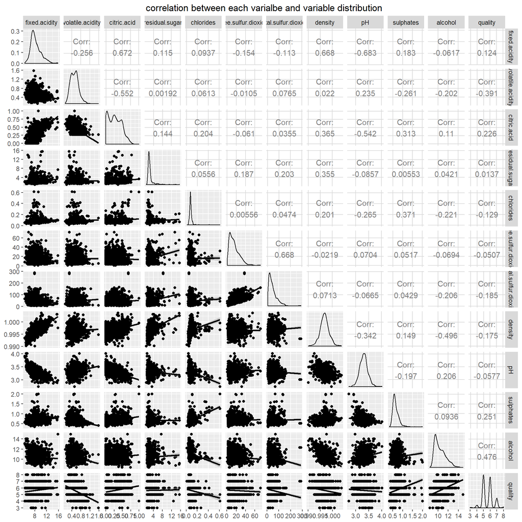

1. Factor of Highest coefficient with quality is alcohol. Coeffecient is 0.476
2. Factor of second highes coefficient with quality is volatile.acidity.  
   Coeffecient is -0.391

### more plot on coefficient chart.

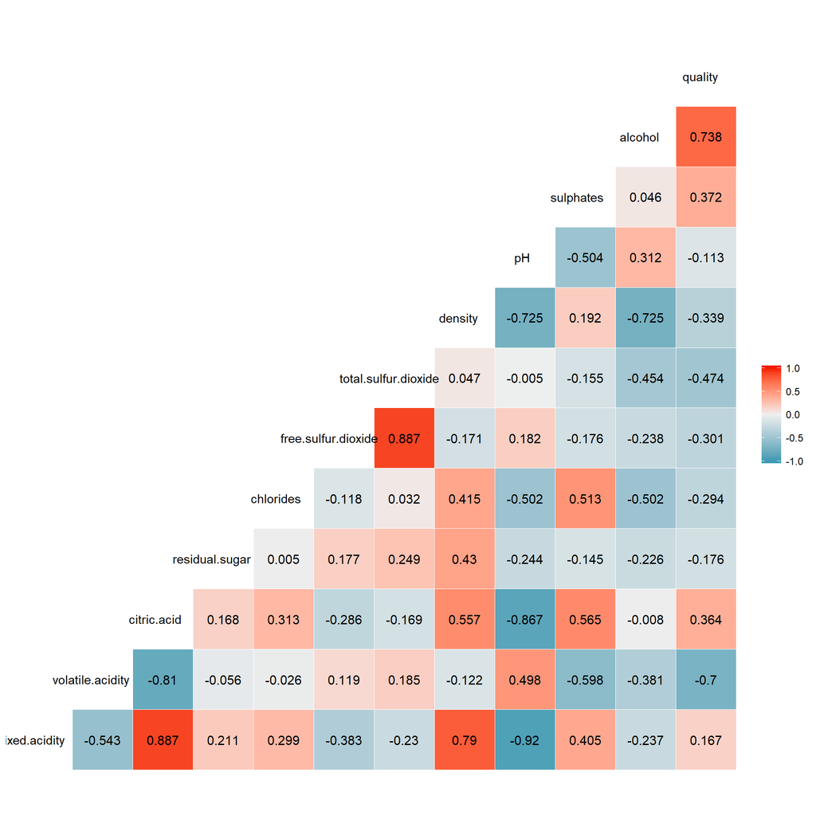

### plot relationship between fixed.acidity and volatile.acidity

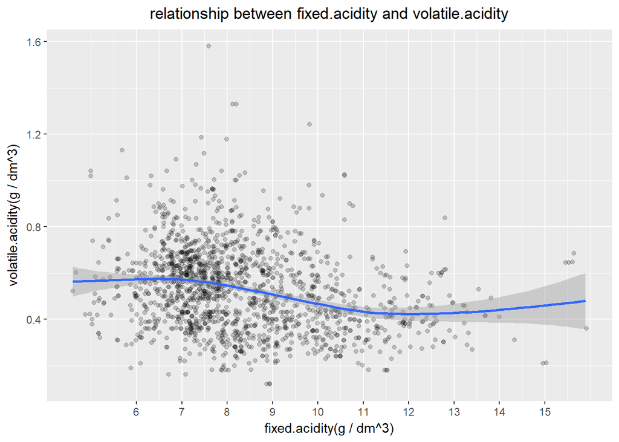

### correlation between fixed.acidity and volatile.acidity

```
## [1] -0.2561309
```

Assume both factors should have strong positive correlation.  
actual two variable have a little negative correlation, which against  
my expectation

### plot relationship between volatile.acidity and sulphates

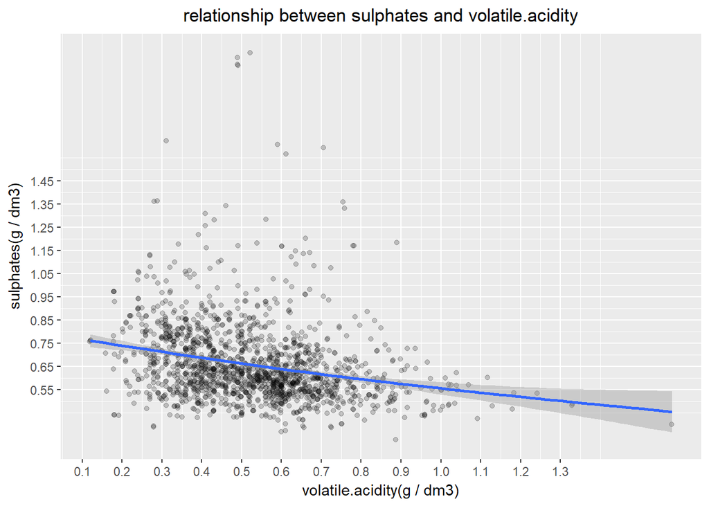

### correlation between sulphates and volatile.acidity

```
## [1] -0.2609867
```

actual two variable have a little negative correlation

### plot relationship between alcohol and quality

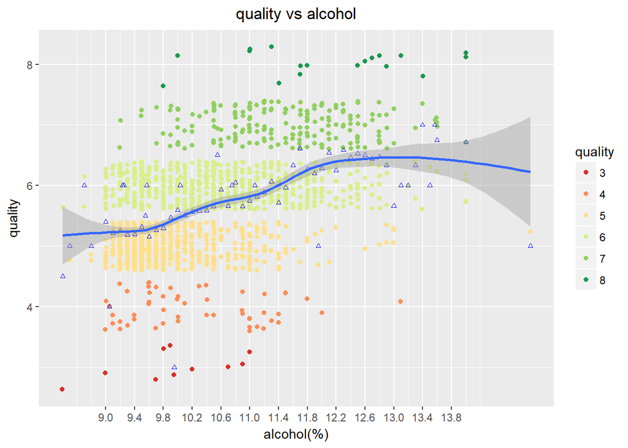

show indication that with the increase of the average alcohol (between 9 and 12)  
,the quality is higher.But since the quality category is too much  
and some outlier among

### calculate relationship between quality and average_alcohol

```
## # A tibble: 6 x 2
##   quality average_alcohol
##     <int>           <dbl>
## 1       3            9.96
## 2       4           10.3
## 3       5            9.90
## 4       6           10.6
## 5       7           11.5
## 6       8           12.1
```

### boxplot to take another look of relationship between quality and alcohol

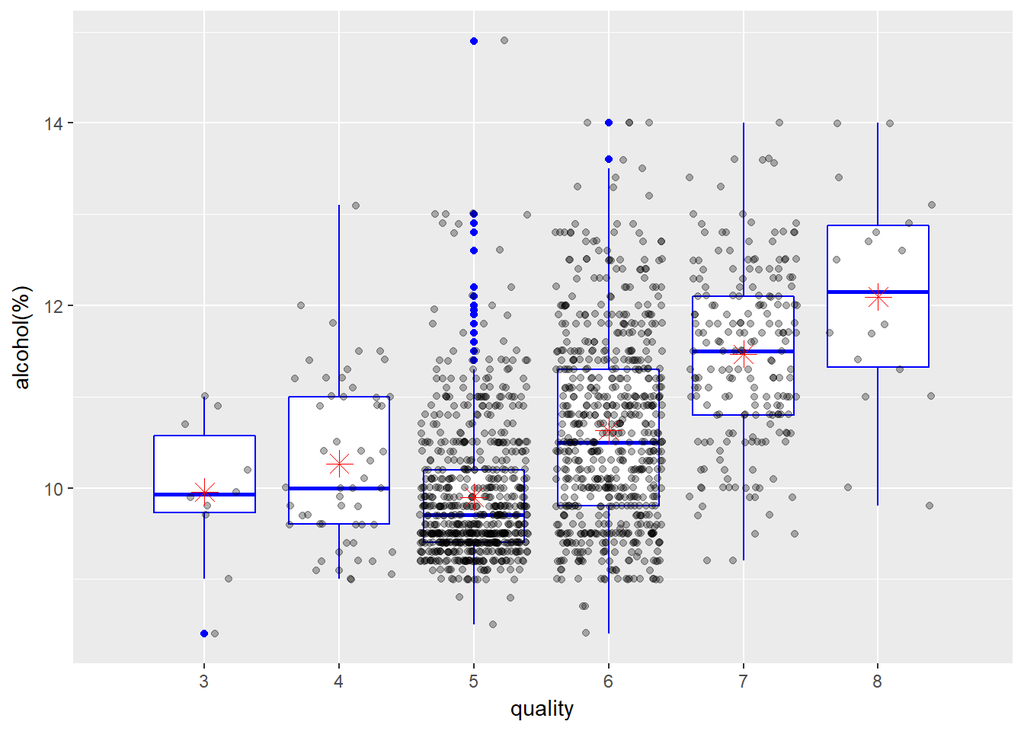

from 5 to 8 quality group,the alcohol level is increasing,  
similar as we discoverd in the scatter plot

### explore relationship between fixed.acidity and quality

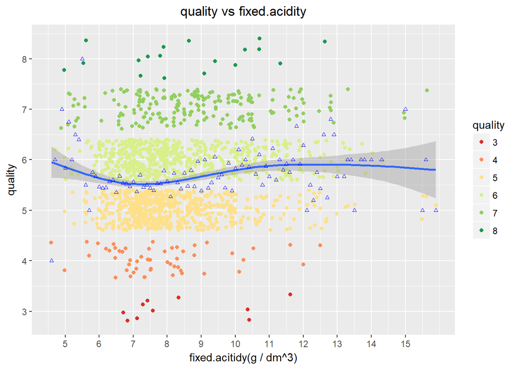

does not show clearn relationship between those two variables

### explore relationship between ph and quality

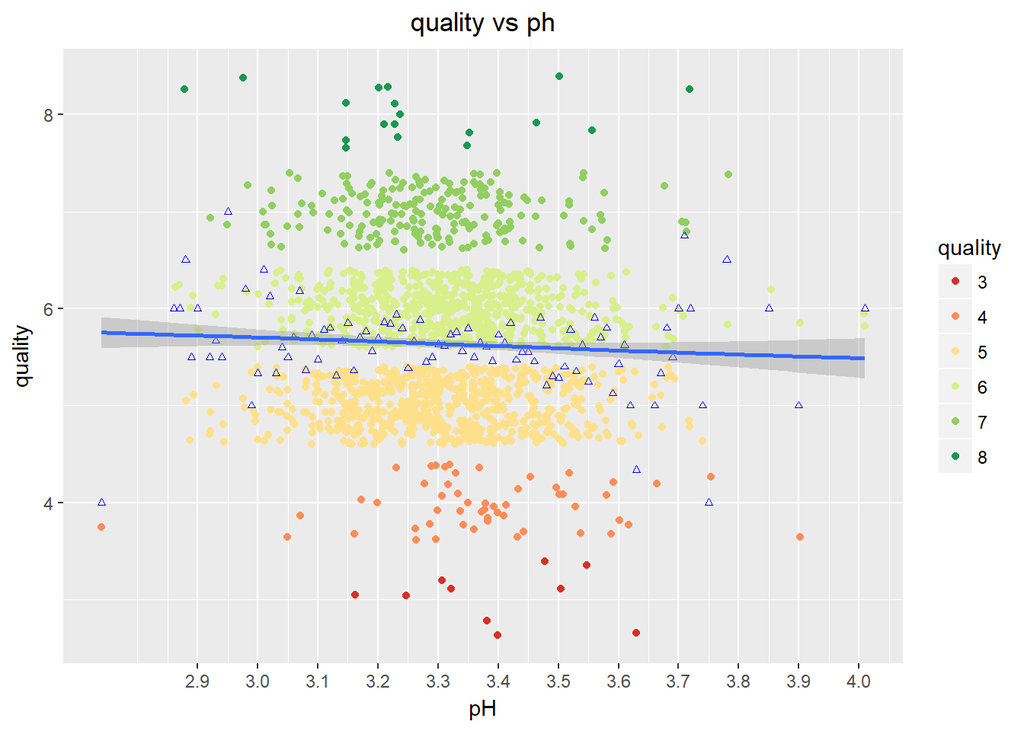

does not show clearn relationship between those two variable

### Explore relationship between volatile.acidity and quality

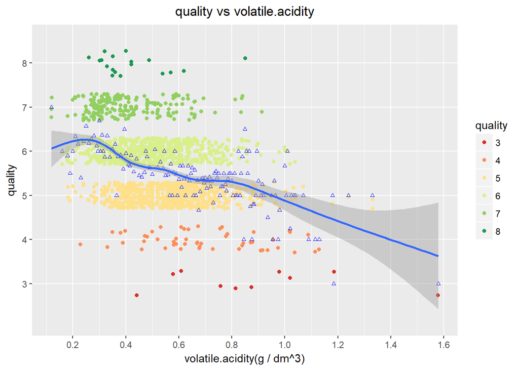

clean indication between volatile.acidity and quality.  
With Volatile.acidity increase, quality decrease

# Bivariate Analysis

### What was the strongest relationship you found?

Most strong relationship I found ti between alcohol and quality.  
If we set limit the applied range, the coefficient will be even higher  
That is why I did winequality factor into the dataset

# Multivariate Plots Section

### alcohol, volatile.acidity and quality relatinship

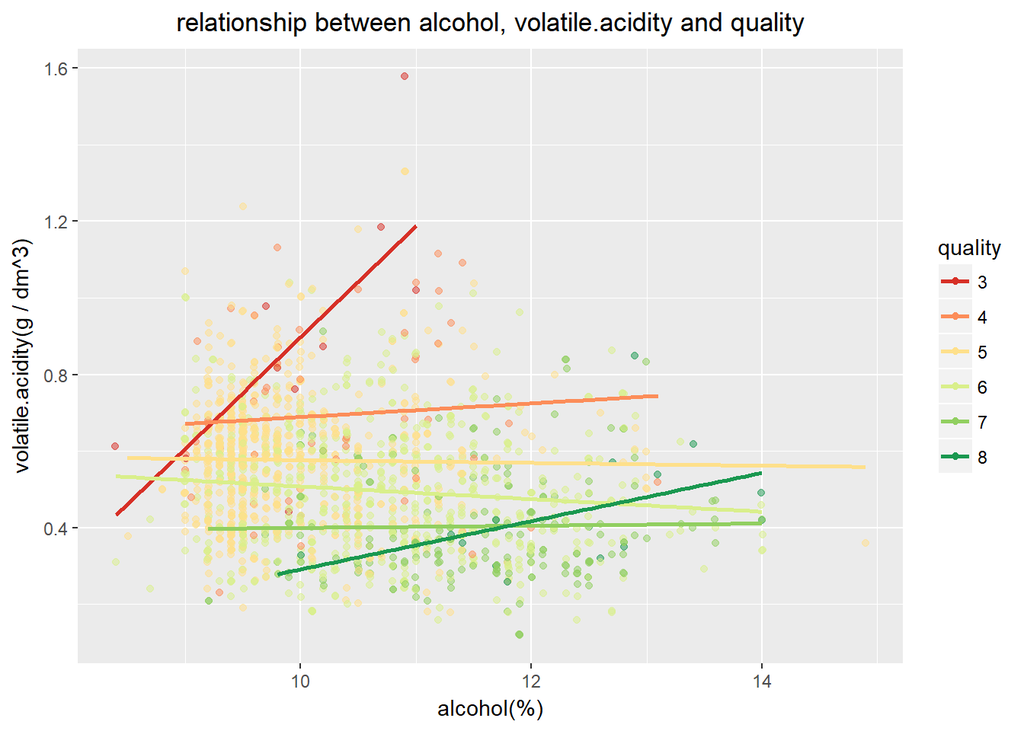

we can see the trend that. Most high quality with high alcohol  
and lower volatile.acidity lower quality of wine  
However, the trend is not clear since we have 6 category of quality  
and some sample is outlier with volatile.acidity. Let’s use group quality  
together and remove some outlier from data

### scatter map among quality, alchohol and volatile.acidity

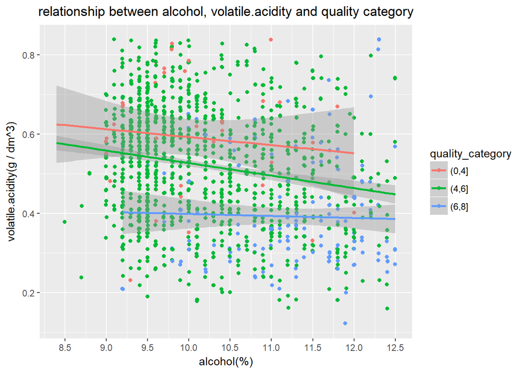

Much clear relationship between quiality, alchohol and volatile.acidity.  
very few sample from (0,4] group. For (4,6] and (6,8] shows clear indication  
between alcohol and violatile .acidity. (Higher quality group tend to  
have high alcohol and lower volatile.acidity)

# Multivariate Analysis

### using mtable to try different parameter for linear regression model

```
##
## Calls:
## m1: lm(formula = I(quality) ~ I(alcohol), data = winequalitydata)
## m2: lm(formula = I(quality) ~ I(alcohol) + volatile.acidity, data = winequalitydata)
## m3: lm(formula = I(quality) ~ I(alcohol) + volatile.acidity + sulphates,
##     data = winequalitydata)
##
## ==============================================================
##                          m1            m2            m3
## --------------------------------------------------------------
##   (Intercept)           1.875***      3.095***      2.611***
##                        (0.175)       (0.184)       (0.196)
##   I(alcohol)            0.361***      0.314***      0.309***
##                        (0.017)       (0.016)       (0.016)
##   volatile.acidity                   -1.384***     -1.221***
##                                      (0.095)       (0.097)
##   sulphates                                         0.679***
##                                                    (0.101)
## --------------------------------------------------------------
##   R-squared             0.227         0.317         0.336
##   adj. R-squared        0.226         0.316         0.335
##   sigma                 0.710         0.668         0.659
##   F                   468.267       370.379       268.912
##   p                     0.000         0.000         0.000
##   Log-likelihood    -1721.057     -1621.814     -1599.384
##   Deviance            805.870       711.796       692.105
##   AIC                3448.114      3251.628      3208.768
##   BIC                3464.245      3273.136      3235.654
##   N                  1599          1599          1599
## ==============================================================
```

even with 3 different variable. R-squared is not really good.  
only explain 33.6 percent fo quality. Maybe it is not fit for linear regression model

# Final Plots and Summary

### Plot One

[figure not shown]

```
## (0,4] (4,6] (6,8]
##    63  1319   217
```

```
##
##           3           4           5           6           7           8
## 0.006253909 0.033145716 0.425891182 0.398999375 0.124452783 0.011257036
```

### Description first

Since we are talking about quality, I want to explore the quality distribution  
Most of quality is 5,6. Very few in 3,4,8. Data is very centrialized.  
4 to 6 group accounmt 82%. And that is one of reason I group the middle  
high proportion into one group(4,6] later.so we can focus the big trend  
rather the minor difference

### Plot two

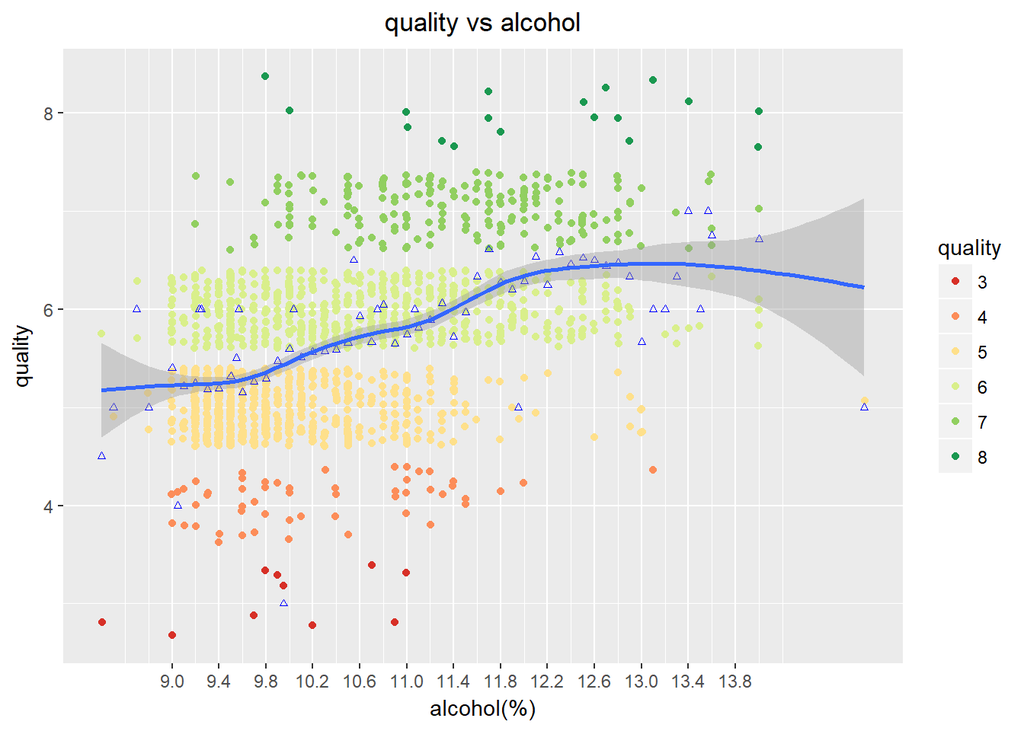

### Description two

Based on GGpair to explore the coeffecient between any two variable, we find  
alcohol have most strong corelation with quality. So, this plot is to visualize  
how that relationship between quality and alcohol  
From the chart, we can tell clean relationship indicating higher alcohol% trend  
to have higher quality, especailly when the alcohol(%) betwween 9.4 to 12.2

### Plot three

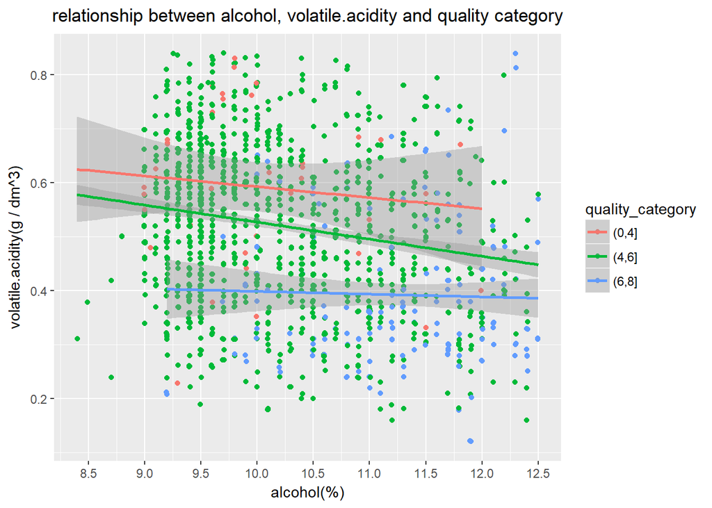

### Description three

From the coeffecient chart information, we can tell that alcohol and volatile.acidity  
are two most influencial factors for qualitys. So, we want to discorver how those  
two factors influence quality simultaneously In order to clear see how alcohol and volatile.acidity influnece the quality  
first, we group similar quality into smaller group so we can see better trend  
Since (0,4] group have few sample, we could not see much trend.  
For (4,6] and (6,8] shows clear indication between alcohol and violatile .acidity  
(Higher quality group tend to have high alcohol and lower volatile.acidity)

# Reflection

Previous, I think ph should have strong relationship with quality. However  
that does not supported by data.

Previous, I want to plot based on quality. however, since the category variable have 6 different values, it will difficult to distinguish the different.  
After group those 6 different value into 3 ban, the trend is more clear  
and we filter out some information which is less important.  
In addition, even with those two factors + sulphates,  
regression model indicates can only explain 33% data in the dataset  
we need to large dataset or other model to predict the quality of wine